# Zadanie 1

Autori: Bc. Dávid Kováľ, Bc. Dominik Klušák

2024-03-30

## Zadanie

Implementujte a natrénujte viacnásobné regresné a klasifikačné modely v programovacom jazyku R a Tidyverse tak, aby boli úspešné (>> lepší ako náhoda) na vami zvolenom probléme.

## Načítanie datasetu

Dataset pozostáva z výsledkov medzinárodných futbalových zápasov konajúcich sa až od roku 1872 až do roku 2024. Rozsah zápasov je od zápasov FIFA až po priateľské futbalové zápasy. V datasete sa nenachádzajú ženské zápasy, zápasy z olympijských hier, U-23 (zápasy do 23 rokov)

```r
matches <- read_csv("results.csv")
```

## Základné operácie s datasetom

1. Ako prvý krok si zobrazíme ukážku, ako vyzerá náš dataset - názvy stĺpcov a ukážka konkrétnych hodnôt/dát.

```r
head(matches)
```

```
## # A tibble: 6 × 9
##   date       home_team away_team home_score away_score tournament city   country
##   <date>     <chr>     <chr>          <dbl>      <dbl> <chr>      <chr>  <chr>
## 1 1872-11-30 Scotland  England            0          0 Friendly   Glasg… Scotla…
## 2 1873-03-08 England   Scotland           4          2 Friendly   London England
## 3 1874-03-07 Scotland  England            2          1 Friendly   Glasg… Scotla…
## 4 1875-03-06 England   Scotland           2          2 Friendly   London England
## 5 1876-03-04 Scotland  England            3          0 Friendly   Glasg… Scotla…
## 6 1876-03-25 Scotland  Wales              4          0 Friendly   Glasg… Scotla…
## # ℹ 1 more variable: neutral <lgl>
```

Vo výstupnej tabuľke môžeme vidieť, že futbalové zápasy sú usporiadané od najstaršieho zápasu. Za dátumom nasleduje domáci tím a hosťovací tím, skóre domácich a hostí, typ turnaja, mesto a krajina, v ktorom sa odohralo futbalové stretnutie a logická hodnota neutral, ktorá označuje, či sa zápas odohral na neutrálnom mieste. V stĺpcoch home_score a away_score sa berú do úvahy aj góly strelené v predĺžení, avšak pokiaľ mal zápas aj penaltový rozstrel, tieto góly neboli započítané do výsledného skóre

```r
spec(matches)
```

[output not shown]

3. V treťom kroku sme si zistili, či sa v našom datasete nachádzajú chýbajúce hodnoty v riadkoch. To sa dá zistiť pomocou príkazu is_na(). Následne vo výpise vidíme, že nám v datasete nechýbajú žiadne hodnoty a teda dataset je úplný.

```r
missing_values <- colSums(is.na(matches))
print(missing_values)
```

```
##       date  home_team  away_team home_score away_score tournament       city
##          0          0          0          0          0          0          0
##    country    neutral
##          0          0
```

4. V poslednom kroku sme si vypísali súhrn základných štatistických informácii pre náš dataset, napríklad hodnoty medián, maximálne hodnoty, počet hodnôt, priemerné hodnoty.

```r
summary(matches)
```

```
##       date             home_team          away_team           home_score
##  Min.   :1872-11-30   Length:46442       Length:46442       Min.   : 0.000
##  1st Qu.:1979-07-15   Class :character   Class :character   1st Qu.: 1.000
##  Median :1999-06-13   Mode  :character   Mode  :character   Median : 1.000
##  Mean   :1992-12-19                                         Mean   : 1.752
##  3rd Qu.:2011-10-08                                         3rd Qu.: 2.000
##  Max.   :2024-03-26                                         Max.   :31.000
##    away_score      tournament            city             country
##  Min.   : 0.000   Length:46442       Length:46442       Length:46442
##  1st Qu.: 0.000   Class :character   Class :character   Class :character
##  Median : 1.000   Mode  :character   Mode  :character   Mode  :character
##  Mean   : 1.184
##  3rd Qu.: 2.000
##  Max.   :21.000
##   neutral
##  Mode :logical
##  FALSE:34506
##  TRUE :11936
##
##
##
```

## Príprava datasetu na hypotézy

Keďže v našich hypotézach, ktoré sú definované nižšie v projekte, budeme využívať štatistiky a pojmy ako výhra, prehra alebo remíza, tak sme si vytvorili nový stĺpec “OUTCOME”, kde sa zapisuje, či domáce mužstvo si pripísalo výhru, prehru alebo remízu.

```r
matches$date <- as.Date(matches$date)

matches <- matches %>%
  mutate(outcome = case_when(
    home_score > away_score ~ "win",
    home_score < away_score ~ "lose",
    TRUE ~ "draw"
  ))
```

Následne smne si vykreslili graf cez “ggplot” pre domáce mužstvá s počtom výhier, počtom prehier a počtom remíz. Podľa grafu vieme vyčítať, že tímy, ktoré hrajú na domácej pôde, majú tendenciu zápas vyhrať > prehrať > remizovať.

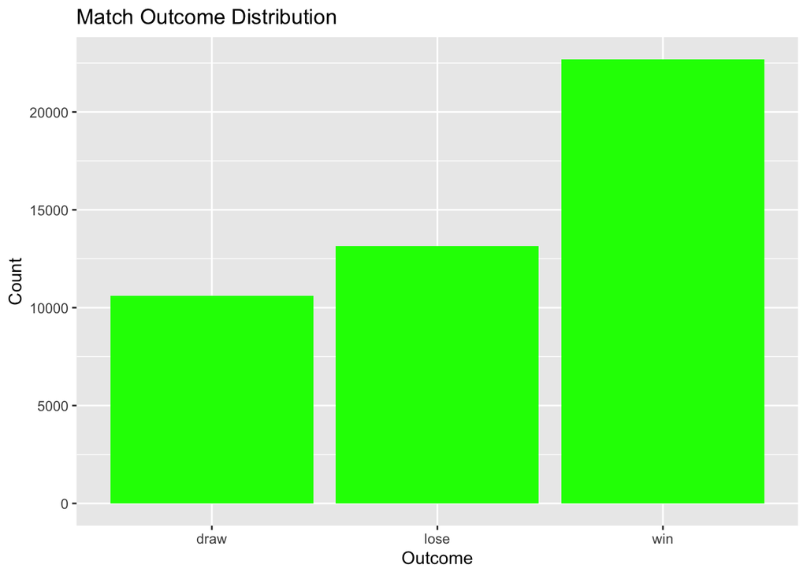

```r
ggplot(matches, aes(x = outcome)) + geom_bar(fill = "green") +
  ggtitle("Match Outcome Distribution") + xlab("Outcome") + ylab("Count")
```

V ďalšom kroku sme pomocou grafou (opäť cez “ggplot” vykreslili distribúciu skóre domácich tímov, hosťujúcich tímov. Na začiatok sme si zhrnuli hodnoty home_score a away_score. Na grafoch tvoria os X skóre (domáce aj hosťujúce tímy) a os Y frekvencia skóre.

```r
summary(matches[ , c("home_score", "away_score")])
```

```
##    home_score       away_score
##  Min.   : 0.000   Min.   : 0.000
##  1st Qu.: 1.000   1st Qu.: 0.000
##  Median : 1.000   Median : 1.000
##  Mean   : 1.752   Mean   : 1.184
##  3rd Qu.: 2.000   3rd Qu.: 2.000
##  Max.   :31.000   Max.   :21.000
```

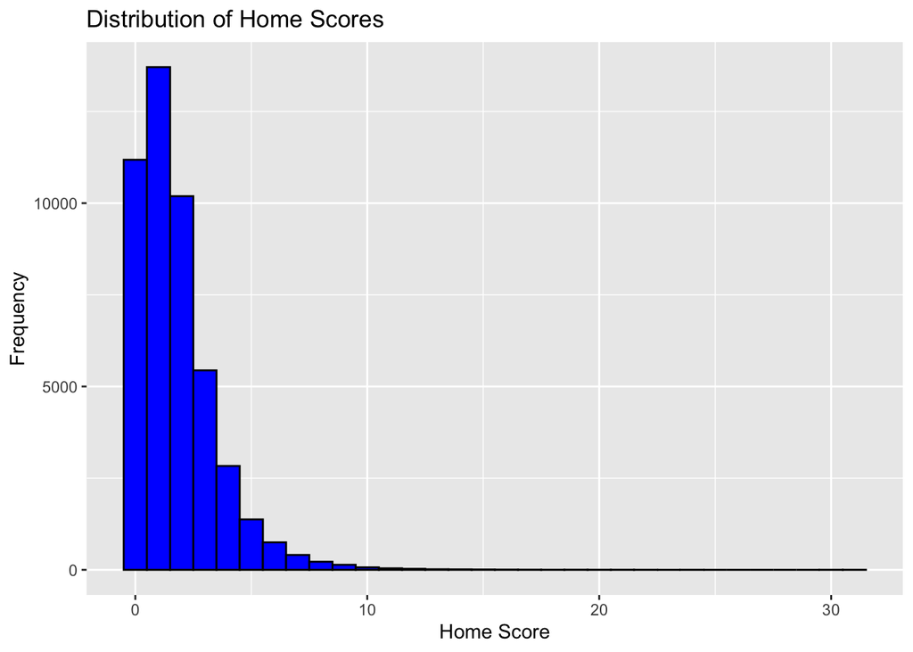

```r
# Distribution of home and away scores
ggplot(matches, aes(x = home_score)) + geom_histogram(binwidth = 1, fill = "blue", color = "black") +
  ggtitle("Distribution of Home Scores") + xlab("Home Score") + ylab("Frequency")
```

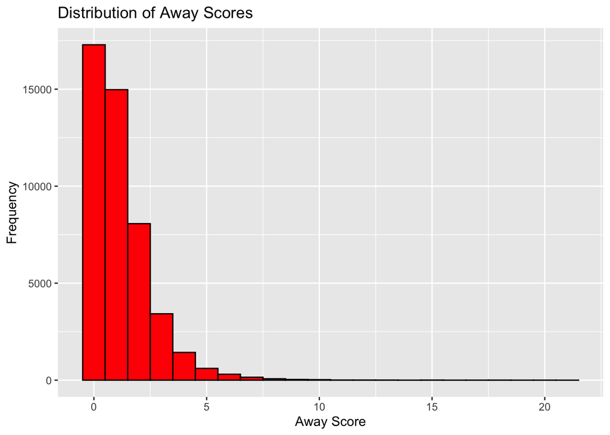

```r
ggplot(matches, aes(x = away_score)) + geom_histogram(binwidth = 1, fill = "red", color = "black") +
  ggtitle("Distribution of Away Scores") + xlab("Away Score") + ylab("Frequency")
```

Zobrazenie outlayerov sme robili pomocou boxplotov, ide o užitočné grafy pre vizualizáciu distribúcie skóre a identifikáciu outlierov, ktoré technicky môžu ovplyvniť analýzu regresie.

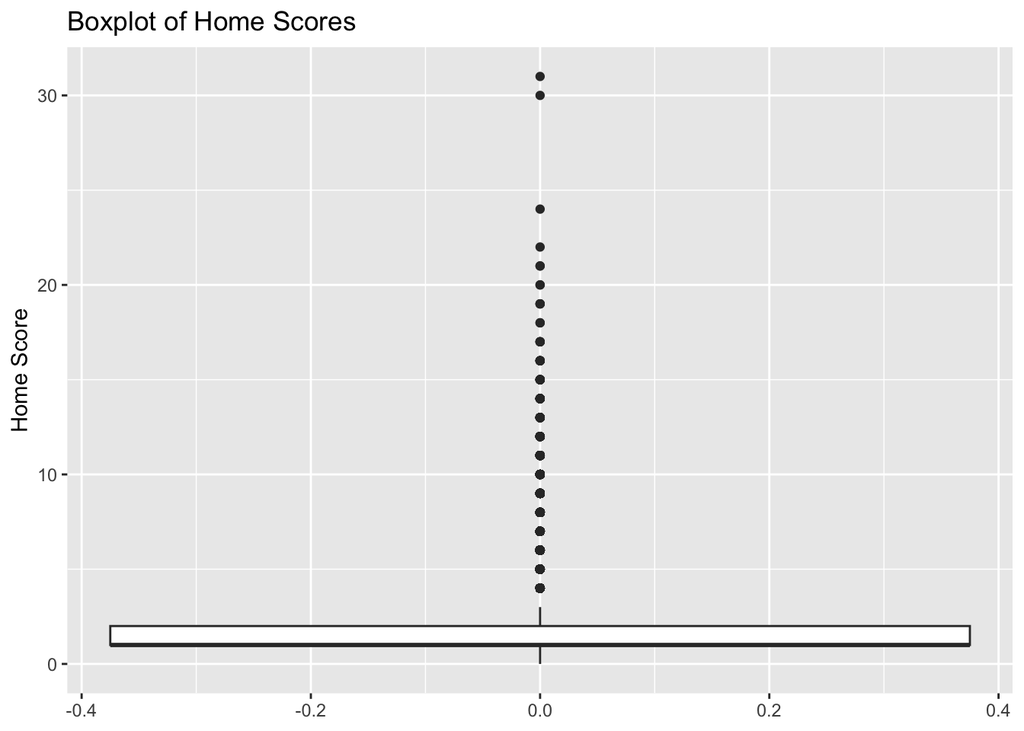

```r
# Boxplot for home scores to identify outliers
ggplot(matches, aes(y = home_score)) + geom_boxplot() +
   ggtitle("Boxplot of Home Scores") + ylab("Home Score")
```

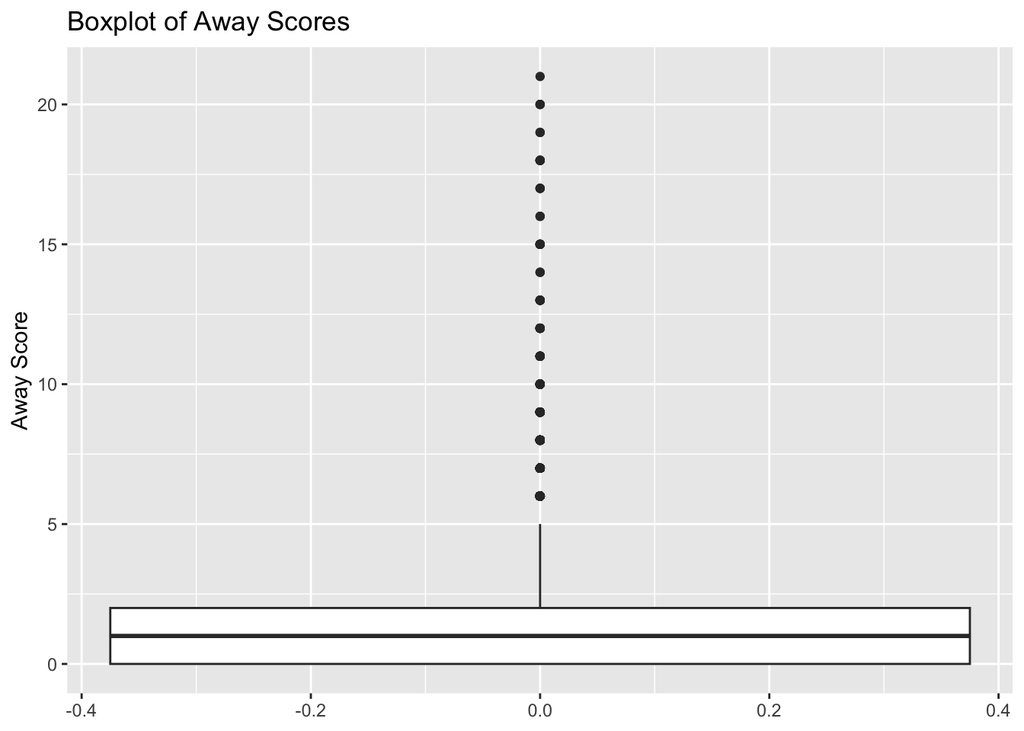

```r
# Boxplot for away scores to identify outliers
ggplot(matches, aes(y = away_score)) + geom_boxplot() +
  ggtitle("Boxplot of Away Scores") + ylab("Away Score")
```

Aj keď tieto hodnoty môžu skutočne reprezentovať reálne výsledky zápasov, môže sa stať že skresia analýzu regresie tým, že zvýšia variabilitu alebo ovplyvnia odhadované parametre modelu. Keďže však ide o reálne výsledky zo zápasov a teda ide o prirodzenú variaciu tohto skóre rozdohli sme sa ich neodstraňovať.

## Regresia - Hypotéza č.1:

Na začiatok si natrénujeme lineárny regresný model cez príkaz “lm”. Tento model budeme ukladať do premennej “lm_model” s nasledovnými vstupnými parametrami: home_score, away_score, neutral (či sa zápas odohráva na neutrálonom mieste) a tournament (typ turnaja).

Pre sumarizáciu, snažíme sa predpovedať domáce skóre na základe skóre hostí, neutrality miesta a typu turnaja.

```r
lm_model <- lm(home_score ~ away_score + neutral + factor(tournament), data = matches)
```

## Klasifikácia - Hypotéza č.2:

Hypotéza č.2: Výsledok zápasu pre domáci tím (výhra, prehra, remíza) možno klasifikovať na základe podobných faktorov.

Na predpovedanie výsledku zápasu použijeme multinomiálny model. Budeme predpovedať výsledok zápasu na základe premenných: away_score, neutral a typ turnaja (tournament).

```r
library(nnet)
multinom_model <- multinom(outcome ~ away_score + neutral + factor(tournament), data = matches)
```

## Výsledky a výstupy

Predpovedané hodnoty domáceho skóre cez jednoduchý regresný model sa uložia do premmej “predicted_scores” pomocou funkcie predict(). Argumentami funkcie je lineárny regresný model “lm_model” a typ response. Takisto sme si vypočítali strednú absolútnu chybu (MAE) a RMSE (odmocnina z priemeru štvorcov chýb).

MAE nám vyjadruje absolútny rozdiel medzi predpoveďami odpovedí a skutočnými odpoveďami. RMSE je podobná metrika, avšak namiesto absolútnzch hodnôt používa druhú mocninu.

```r
predicted_scores <- predict(lm_model, type = "response")
MAE <- mean(abs(predicted_scores - matches$home_score))
RMSE <- sqrt(mean((predicted_scores - matches$home_score)^2))

print(MAE)
```

```
## [1] 1.254399
```

```r
print(RMSE)
```

```
## [1] 1.718562
```

Výsledky z klasifikácie pomocou multinomiálneho modelu sú ukladané do premennej “predicted_outcomes”. Následne predikované výsledky konvertujeme na faktorovú premennú s triedami win, lose a draw (výhra, prehra, remíza) a následne konvertujeme skutočné výsledky z datasetu na faktorovú premennú s rovnakými triedami. Na záver sme znázornili tabuľku, ktorá nám porovnáva predpovedané výsledky (premenná predicted_outcomes_factor) s reálnymi výsledkami (matches$outcome_factor) a takisto nám vypočíta počet správnych a nesprávnych klasifikácii.

```r
library(caret)
```

```r
# Convert both predicted outcomes and actual outcomes to factors with the same levels

predicted_outcomes <- predict(multinom_model, newdata = matches, type = "class")

predicted_outcomes_factor <- factor(predicted_outcomes, levels = c("win", "lose", "draw"))
matches$outcome_factor <- factor(matches$outcome, levels = c("win", "lose", "draw"))

#Confusion matrix
confusion_matrix_result <- confusionMatrix(data = predicted_outcomes_factor, reference = matches$outcome_factor)

#Results
print(confusion_matrix_result)
```

```
## Confusion Matrix and Statistics
##
##           Reference
## Prediction   win  lose  draw
##       win  20637  3194  8282
##       lose  1959  9875  2191
##       draw    95    88   121
##
## Overall Statistics
##
##                Accuracy : 0.6596
##                  95% CI : (0.6553, 0.6639)
##     No Information Rate : 0.4886
##     P-Value [Acc > NIR] : < 2.2e-16
##
##                   Kappa : 0.4081
##
##  Mcnemar's Test P-Value : < 2.2e-16
##
## Statistics by Class:
##
##                      Class: win Class: lose Class: draw
## Sensitivity              0.9095      0.7506    0.011422
## Specificity              0.5168      0.8753    0.994895
## Pos Pred Value           0.6426      0.7041    0.398026
## Neg Pred Value           0.8567      0.8988    0.773007
## Prevalence               0.4886      0.2833    0.228112
## Detection Rate           0.4444      0.2126    0.002605
## Detection Prevalence     0.6915      0.3020    0.006546
## Balanced Accuracy        0.7131      0.8129    0.503158
```

## ROC Analýza pre klasifikačný model

Po natrénovaní nášho multinomiálneho logistického regresného modelu sme vykonali ROC analýzu. ROC krivka a AUC (Area Under the Curve) hodnota nám pomáhajú zhodnotiť schopnosť modelu správne predpovedať výsledky ako ‘výhra’ proti ostatným možnostiam (‘prehra’ alebo ‘remíza’).

```r
library(pROC)
```

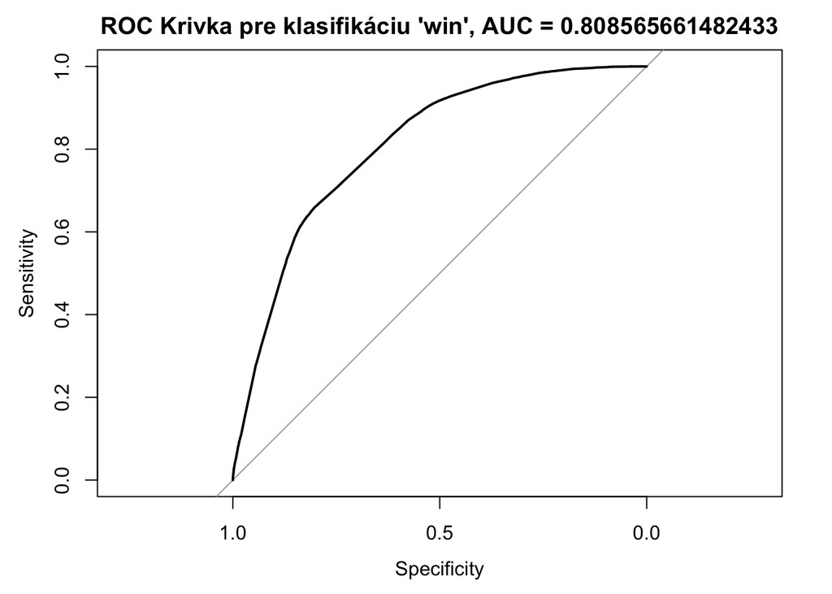

```r
# Získanie predpovedaných pravdepodobností pre klasifikáciu 'win'
predicted_probs <- predict(multinom_model, newdata = matches, type = "prob")

# Prevod skutočných výsledkov na binárnu formu pre klasifikáciu 'win'
matches$binary_outcome <- as.numeric(matches$outcome == "win")
predicted_probs_win <- predicted_probs[,"win"]

# Vytvorenie ROC objektu pre klasifikáciu 'win'
roc_curve <- roc(matches$binary_outcome, predicted_probs_win)
# Výpočet AUC hodnoty pre ROC krivku
auc_value <- auc(roc_curve)

# Vykreslenie ROC krivky
plot(roc_curve, main = paste("ROC Krivka pre klasifikáciu 'win', AUC =", auc_value))
```

```r
# Výpis AUC hodnoty
print(auc_value)
```

```
## Area under the curve: 0.8086
```